```python
!pip install -U ipykernel
```

# Importing Libraries

###### Here, we have imported pytorch modules as well as some useful util libraries such as numpy, pandas as and matplotlib to achieve various functionalities and support

After that we have mounted our google drive as we have uploaded our dataset on google drive.

PS:- Please change your runtime to GPU for expedite results

```python
import torch
import torch.nn as nn

import torch.nn.functional as F
from torch.utils.data import DataLoader
from torchvision import datasets, transforms, models
from torchvision.utils import make_grid
import os
import tensorflow as tf

import numpy as np
import pandas as pd
import matplotlib.pyplot as plt
%matplotlib inline
```

```python
!pip install dataloader
```

```python
from google.colab import drive
drive.mount('/content/drive')
```

```python
from pathlib import Path
p = Path().cwd()
q = p / 'drive'/'MyDrive'/'Capstone'
```

# Tranformation

```python
train_transform = transforms.Compose([
                  transforms.RandomRotation(10),
                  transforms.RandomHorizontalFlip(),
                  transforms.Resize(227),
                  transforms.CenterCrop(227),
                  transforms.ToTensor(),
                  transforms.Normalize([0.485, 0.456, 0.406],
                                       [0.229, 0.224, 0.225])
])

test_transform = transforms.Compose([
                  transforms.Resize(227),
                  transforms.CenterCrop(227),
                  transforms.ToTensor(),
                  transforms.Normalize([0.485, 0.456, 0.406],
                                       [0.229, 0.224, 2.225])
])
```

# Load dataset using dataloader

By giving location of google drive, we have loaded images with previously defined tranformation function.

We have also printed out class names and number of images in training and testing class.

```python
root = "/content/drive/MyDrive/Capstone/FinalDataset/train"

testing_root = "/content/drive/MyDrive/Capstone/FinalDataset/test"
```

```python
train_data = datasets.ImageFolder(root,transform=train_transform)
test_data = datasets.ImageFolder(testing_root, transform=test_transform)

torch.manual_seed(42)
train_loader = DataLoader(train_data, batch_size=32, shuffle=True)
test_loader = DataLoader(test_data, batch_size=32, shuffle=True)

class_names = train_data.classes

print(class_names)
print(f'Training images available: {len(train_data)}')
print(f'Testing images available:  {len(test_data)}')
```

```
['N95', 'N95Valve', 'NoMask', 'colth', 'surgical']
Training images available: 9990
Testing images available:  5886
```

```python
CATEGORIES = ['cloth','N95','N95Valve','NoMask','Surgical']
dic = {'cloth':0,'N95':0,'N95Valve':0,'NoMask':0,'Surgical':0}

for category in CATEGORIES:
    path = os.path.join(root, category)
    print(path)

    #for img in os.listdir(path):
        #img_path = os.path.join(path, img)

        #try:
            #print("1")
        #except:
            #pass
```

```
/content/drive/MyDrive/Capstone/FinalDataset/train/cloth
/content/drive/MyDrive/Capstone/FinalDataset/train/N95
/content/drive/MyDrive/Capstone/FinalDataset/train/N95Valve
/content/drive/MyDrive/Capstone/FinalDataset/train/NoMask
/content/drive/MyDrive/Capstone/FinalDataset/train/Surgical
```

# Display a batch of images

to verify that the training loader selects all classes at random, we are showing a batch of images. We have applied transformation at last to inverse effect of our tranformation

```
Label: [2 2 2 3 3 2 2 4 3 2 2 2 2 2 4 2 4 2 4 1 2 2 2 2 2 2 2 2 2 2 2 4]
Class: NoMask NoMask NoMask colth colth NoMask NoMask surgical colth NoMask NoMask NoMask NoMask NoMask surgical NoMask surgical NoMask surgical N95Valve NoMask NoMask NoMask NoMask NoMask NoMask NoMask NoMask NoMask NoMask NoMask surgical
```

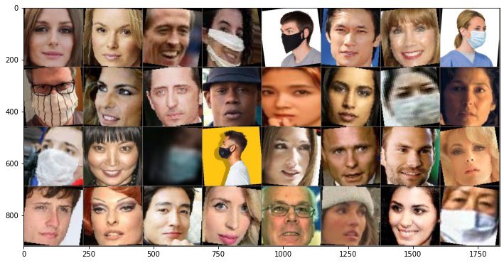

```python
# Grab the first batch of 10 images
for images,labels in train_loader:
    break

# Print the labels
print('Label:', labels.numpy())
print('Class:', *np.array([class_names[i] for i in labels]))

im = make_grid(images, nrow=8)  # the default nrow is 8

# Inverse normalize the images
inv_normalize = transforms.Normalize(
    mean=[-0.485/0.229, -0.456/0.224, -0.406/0.225],
    std=[1/0.229, 1/0.224, 1/0.225]
)
im_inv = inv_normalize(im)

# Print the images
plt.figure(figsize=(12,12))
plt.imshow(np.transpose(im_inv.numpy(), (1, 2, 0)));
```

# Define the model

```python
class ConvolutionalNetwork(nn.Module):
    def __init__(self):
        super().__init__()
        self.conv1 = nn.Conv2d(3, 16, 3, 1)
        self.conv2 = nn.Conv2d(16, 32, 3, 1)
        self.conv3 = nn.Conv2d(32, 64, 3, 1)
        self.fc1 = nn.Linear(26*26*64, 128)
        self.fc2 = nn.Linear(128, 64)
        self.fc3 = nn.Linear(64, 32)
        self.fc4 = nn.Linear(32, 5)
        self.norm1 = nn.BatchNorm2d(16)
        self.norm2 = nn.BatchNorm2d(32)
        self.norm3 = nn.BatchNorm2d(64)
        self.dropOut = nn.Dropout(p=0.2)

    def forward(self, X):
        # print(X.shape)
        X = F.leaky_relu(self.conv1(X))
        # print(X.shape)
        X = F.max_pool2d(X, 2, 2)
        X = self.norm1(X)
        # print(X.shape)

        X = F.leaky_relu(self.conv2(X))
        # print(X.shape)
        X = F.max_pool2d(X, 2, 2)
        X = self.norm2(X)
        # print(X.shape)

        X = F.leaky_relu(self.conv3(X))
        # print(X.shape)
        X = F.max_pool2d(X, 2, 2)
        X = self.norm3(X)
        # print(X.shape)

        X = X.view(-1, 26*26*64)
        # print(X.shape)
        X = F.leaky_relu(self.fc1(X))
        # print(X.shape)
        X = self.dropOut(X)
        # print(X.shape)
        X = F.leaky_relu(self.fc2(X))
        # print(X.shape)
        X = self.dropOut(X)
        # print(X.shape)
        X = F.leaky_relu(self.fc3(X))
        # print(X.shape)
        X = self.dropOut(X)
        # print(X.shape)
        X = self.fc4(X)
        # print(X.shape,"done")
        return F.log_softmax(X, dim=1)
```

### Instantiate the model, define loss and optimization functions

We are using CrossEntropyLoss as our loss function and SGD(stochastic gradient descent) with learning rate of 0.07 and weight decay of 0.001

```python
CNNmodel = ConvolutionalNetwork()
criterion = nn.CrossEntropyLoss()
optimizer = torch.optim.SGD(CNNmodel.parameters(), lr=0.07, weight_decay=0.001)
CNNmodel
```

```
ConvolutionalNetwork(
  (conv1): Conv2d(3, 16, kernel_size=(3, 3), stride=(1, 1))
  (conv2): Conv2d(16, 32, kernel_size=(3, 3), stride=(1, 1))
  (conv3): Conv2d(32, 64, kernel_size=(3, 3), stride=(1, 1))
  (fc1): Linear(in_features=43264, out_features=128, bias=True)
  (fc2): Linear(in_features=128, out_features=64, bias=True)
  (fc3): Linear(in_features=64, out_features=32, bias=True)
  (fc4): Linear(in_features=32, out_features=5, bias=True)
  (norm1): BatchNorm2d(16, eps=1e-05, momentum=0.1, affine=True, track_running_stats=True)
  (norm2): BatchNorm2d(32, eps=1e-05, momentum=0.1, affine=True, track_running_stats=True)
  (norm3): BatchNorm2d(64, eps=1e-05, momentum=0.1, affine=True, track_running_stats=True)
  (dropOut): Dropout(p=0.2, inplace=False)
)
```

# Train the model

We have 9990 images for trainig and we have 5886 for validation(We are going to use testing as validation as of now). Here, We will trainf our model for 10 epochs and we wil keep track of loss function.

Difference between training and testing step is, we aren't allowed to do back-propogation while perfoming validation as it wil change weight and it considers as training part.

```python
import time
start_time = time.time()

epochs = 10

train_losses = []
test_losses = []
train_correct = []
test_correct = []

for i in range(epochs):
    trn_corr = 0
    tst_corr = 0

    # Run the training batches
    for b, (X_train, y_train) in enumerate(train_loader):

        # Limit the number of batches
        b+=1

        # Apply the model
        y_pred = CNNmodel(X_train)
        loss = criterion(y_pred, y_train)

        # Tally the number of correct predictions
        predicted = torch.max(y_pred.data, 1)[1]
        batch_corr = (predicted == y_train).sum()
        trn_corr += batch_corr

        # Update parameters
        optimizer.zero_grad()
        loss.backward()
        optimizer.step()

        # Print interim results
        if b%10 == 0:
            print(f'epoch: {i:2}  batch: {b:4}   loss: {loss.item():10.8f} accuracy: {trn_corr.item()*100/(b*32):7.3f}%')

    train_losses.append(loss)
    train_correct.append(trn_corr)

    # Run the testing batches
    with torch.no_grad():
        for b, (X_test, y_test) in enumerate(test_loader):
            # Limit the number of batches

            # Apply the model
            y_val = CNNmodel(X_test)

            # Tally the number of correct predictions
            predicted = torch.max(y_val.data, 1)[1]
            tst_corr += (predicted == y_test).sum()


    loss = criterion(y_val, y_test)
    test_losses.append(loss)
    test_correct.append(tst_corr)

print(f'\nDuration: {time.time() - start_time:.0f} seconds') # print the time elapsed
```

```
epoch:  0  batch:   10   loss: 0.22635411 accuracy:  95.625%
epoch:  0  batch:   20   loss: 0.08014583 accuracy:  95.312%
epoch:  0  batch:   30   loss: 0.26974070 accuracy:  94.583%
epoch:  0  batch:   40   loss: 0.05715161 accuracy:  94.375%
epoch:  0  batch:   50   loss: 0.13654155 accuracy:  94.938%
epoch:  0  batch:   60   loss: 0.02746137 accuracy:  94.948%
epoch:  0  batch:   70   loss: 0.19632570 accuracy:  94.866%
epoch:  0  batch:   80   loss: 0.15571940 accuracy:  94.883%
epoch:  0  batch:   90   loss: 0.23555151 accuracy:  94.514%
epoch:  0  batch:  100   loss: 0.37225991 accuracy:  94.594%
epoch:  0  batch:  110   loss: 0.24399062 accuracy:  94.517%
epoch:  0  batch:  120   loss: 0.03595553 accuracy:  94.427%
epoch:  0  batch:  130   loss: 0.10830635 accuracy:  94.471%
epoch:  0  batch:  140   loss: 0.22907881 accuracy:  94.531%
epoch:  0  batch:  150   loss: 0.13664101 accuracy:  94.562%
epoch:  0  batch:  160   loss: 0.21269399 accuracy:  94.551%
epoch:  0  batch:  170   loss: 0.09136883 accuracy:  94.485%
epoch:  0  batch:  180   loss: 0.10024843 accuracy:  94.635%
epoch:  0  batch:  190   loss: 0.38008127 accuracy:  94.556%
epoch:  0  batch:  200   loss: 0.19040464 accuracy:  94.562%
epoch:  0  batch:  210   loss: 0.73526752 accuracy:  94.464%
epoch:  0  batch:  220   loss: 0.29476231 accuracy:  94.389%
epoch:  0  batch:  230   loss: 0.35796979 accuracy:  94.389%
epoch:  0  batch:  240   loss: 0.19565809 accuracy:  94.453%
epoch:  0  batch:  250   loss: 0.09774611 accuracy:  94.450%
epoch:  0  batch:  260   loss: 0.10660745 accuracy:  94.483%
epoch:  0  batch:  270   loss: 0.13780579 accuracy:  94.583%
epoch:  0  batch:  280   loss: 0.05283348 accuracy:  94.598%
epoch:  0  batch:  290   loss: 0.45087105 accuracy:  94.547%
epoch:  0  batch:  300   loss: 0.15786685 accuracy:  94.500%
epoch:  0  batch:  310   loss: 0.28086704 accuracy:  94.446%
epoch:  1  batch:   10   loss: 0.11406536 accuracy:  94.062%
epoch:  1  batch:   20   loss: 0.14659883 accuracy:  95.625%
epoch:  1  batch:   30   loss: 0.04787913 accuracy:  95.833%
epoch:  1  batch:   40   loss: 0.06123185 accuracy:  96.016%
epoch:  1  batch:   50   loss: 0.23412216 accuracy:  96.000%
epoch:  1  batch:   60   loss: 0.02711035 accuracy:  95.938%
epoch:  1  batch:   70   loss: 0.29223284 accuracy:  95.670%
epoch:  1  batch:   80   loss: 0.05235380 accuracy:  95.664%
epoch:  1  batch:   90   loss: 0.10326929 accuracy:  95.799%
```

[output cut: 257 more lines]

```
epoch:  9  batch:  190   loss: 0.25659567 accuracy:  97.237%
epoch:  9  batch:  200   loss: 0.07384942 accuracy:  97.266%
epoch:  9  batch:  210   loss: 0.10402306 accuracy:  97.158%
epoch:  9  batch:  220   loss: 0.02596777 accuracy:  97.202%
epoch:  9  batch:  230   loss: 0.07556467 accuracy:  97.215%
epoch:  9  batch:  240   loss: 0.23372030 accuracy:  97.148%
epoch:  9  batch:  250   loss: 0.02289533 accuracy:  97.112%
epoch:  9  batch:  260   loss: 0.06486312 accuracy:  97.188%
epoch:  9  batch:  270   loss: 0.02735052 accuracy:  97.199%
epoch:  9  batch:  280   loss: 0.08882955 accuracy:  97.132%
epoch:  9  batch:  290   loss: 0.11759039 accuracy:  97.080%
epoch:  9  batch:  300   loss: 0.04599388 accuracy:  96.990%
epoch:  9  batch:  310   loss: 0.14657336 accuracy:  96.986%

Duration: 6579 seconds
```

# Accuracy plot

Here, you can see plot of accuracy over the epoch, it's not the best performace when it comes to validation test and we wil try to figure out why

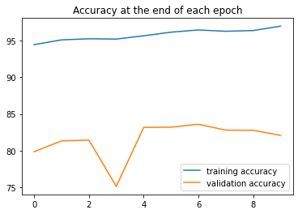

```python
plt.plot([t*100/9990 for t in train_correct], label='training accuracy')
plt.plot([t*100/5886 for t in test_correct], label='validation accuracy')
plt.title('Accuracy at the end of each epoch')
plt.legend()
```

# Evaluation

Here, I have printed out confusion matrix, accuracy, recall, precision and f1 score

```python
from sklearn.metrics import confusion_matrix, accuracy_score, precision_score, recall_score, f1_score
```

```python
y_true = []
y_pred = []
for b, (X_test, y_test) in enumerate(test_loader):
            # Limit the number of batches

            # Apply the model
            y_val = CNNmodel(X_test)

            # Tally the number of correct predictions
            predicted = torch.max(y_val.data, 1)[1]
            y_pred += predicted
            y_true += y_test
            # tst_corr += (predicted == y_test).sum()
```

# Confusion Matrix

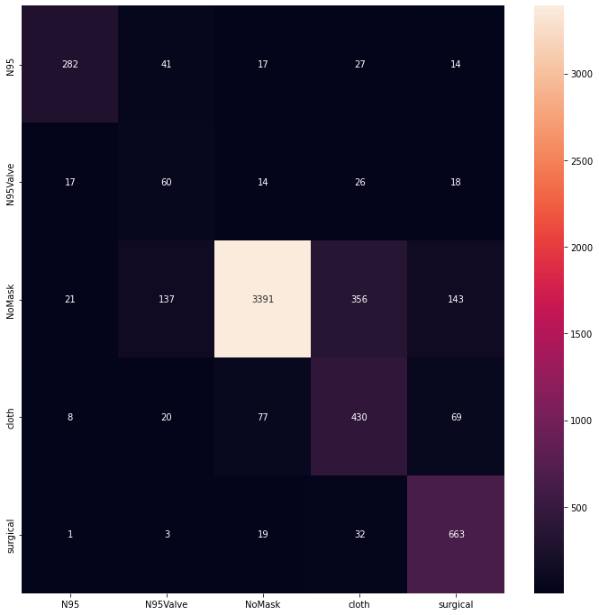

```python
cm = confusion_matrix(y_true, y_pred)
import seaborn as sns
categories = ['N95', 'N95Valve', 'NoMask', 'cloth', 'surgical']
df_cm = pd.DataFrame(cm, categories, categories)
plt.figure(figsize=(12,12))
sns.heatmap(df_cm, annot=True, fmt="g")
```

```python
print("Accuracy of this model is:",accuracy_score(y_true, y_pred))
print("Precision of this model is:",precision_score(y_true, y_pred, average="macro"))
print("Recall of this model is:",recall_score(y_true, y_pred,  average="macro"))
print("F1-Score of this model is:",f1_score(y_true, y_pred,  average="macro"))
```

```
Accuracy of this model is: 0.81991165477404
Precision of this model is: 0.6551189067426082
Recall of this model is: 0.731523682342007
F1-Score of this model is: 0.6785651766449644
```

# Downloading the model

We are downloading the model so , we can use this in future without training again

```python
torch.save(CNNmodel.state_dict(), 'maskModel.pt')
from google.colab import files
files.download('maskModel.pt')
```